# Agglomertive Hierarchical Clustering using Ward Linkage

Group 10 (Yuxuan Hu,Ke Li and Anran Meng)

2018-12-05

$$\newcommand{\R}{\mathbb{R}}
\renewcommand{\vec}[1]{\mathbf{#1}}
\newcommand{\X}{\mathcal{X}}
\newcommand{\D}{\mathcal{D}}
\newcommand{\G}{\mathcal{G}}
\newcommand{\L}{\mathcal{L}}
\newcommand{\X}{\mathcal{X}}
\newcommand{\Parents}{\mathrm{Parents}}
\newcommand{\NonDesc}{\mathrm{NonDesc}}
\newcommand{\I}{\mathcal{I}}
\newcommand{\dsep}{\text{d-sep}}
\newcommand{\Cat}{\mathrm{Categorical}}
\newcommand{\Bin}{\mathrm{Binomial}}$$

# Agglomerative Hierarchical Clustering

As indicated by the term *hierarchical*, the method seeks to build clusters based on hierarchy. Generally, there are two types of clustering strategies: *Agglomerative* and *Divisive*. Here, we mainly focus on the agglomerative approach, which can be easily pictured as a ‘bottom-up’ algorithm.

> Observations are treated separately as singleton clusters. Then, compute the Euclidean distance of each pair and successively merge the most similar clusters. Repeated the previous step until the final optimal clusters are formed.

## Ward Linkage Method

There are four methods for combining clusters in *agglomerative approach*. The one we choose to use is called *Ward’s Method*. Unlike the others. Instead of measuring the distance directly, it analyzes the variance of clusters. Ward’s is said to be the most suitable method for quantitative variables.

[Ward’s method](https://www.stat.cmu.edu/~cshalizi/350/lectures/08/lecture-08.pdf) says that the distance between two clusters, A and B, is how much the sum of squares will increase when we merge them:
$$\Delta(A,B) = \sum_{i\in A \bigcup B} ||\overrightarrow{x_i} - \overrightarrow{m}_{A \bigcup B}||^2 - \sum_{i \in A}||\overrightarrow{x_i} - \overrightarrow{m}_A||^2 -\sum_{i \in B}||\overrightarrow{x_i}- \overrightarrow{m}_B||^2
= \frac{n_An_B}{n_A+n_B} ||\overrightarrow{m}_A- \overrightarrow{m}_B||^2$$

where $\overrightarrow{m}_j$is the center of cluster j, and $n_j$ is the number of points in it. $\Delta$ is called the merging cost of combining the clusters A and B. With hierarchical clustering, the sum of squares starts out at zero (because every point is in its own cluster) and then grows as we merge clusters. Ward’s method keeps this growth as small as possible.

The [Euclidean distance](https://en.wikipedia.org/wiki/Euclidean_distance) is the “ordinary” straight-line distance between two points in Euclidean space.

$$d(p,q) = d(q,p) = \sqrt{(q_1 -p_1)^2 + (q_2 - p_2)^2 + \cdots + (q_n -p_n)^2} = \sqrt{\sum_{i=1} (q_i-p_i)^2}$$

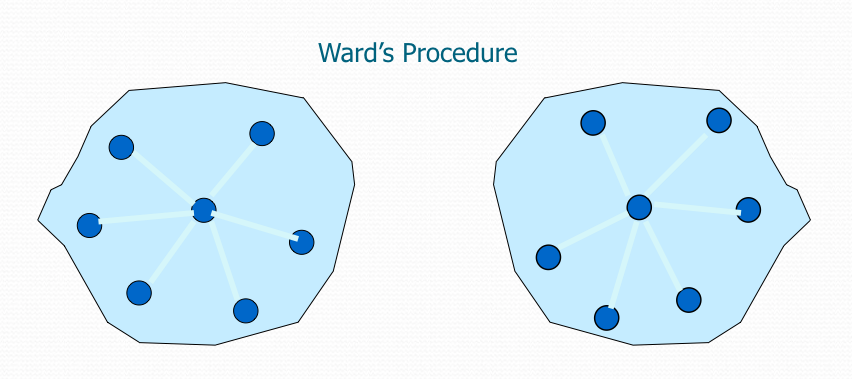

## Calinski and Harabasz Index

*Calinski and Harabasz Index (CH Index)* is often used for choosing the optimal number of clusters. This criterion combines the within and between cluster variance to evalute the quality of segmentation. The formula of *CH Index* defined as:
$$CH(K)=\frac{B(K)/(K-1)}{W(K)/(n-K)}$$
where *W* denotes within-cluster variation, *B* denotes between-cluster variation.

To obtain a small within-cluster variation and large within-cluster variation simultaneously, we would pick the value of K with the largest CH score as the stopping point. Even though in practice, there is limitation in CH index, for simplicity, we use CH Index as our main cluster stopping rule in this project.

## Dataset: [Black Friday](https://www.kaggle.com/mehdidag/black-friday/)

In this tutorial, we choose the dataset on Black Friday with 6 variables. Dataset of 550 000 observations about the black Friday in a retail store, it contains different kinds of variables either numerical or categorical. It also contains missing values.

The description of the variables we use can be found below.

| Variable | Desciption | Range/Unit |
| --- | --- | --- |
| User_ID | User ID | 1000001-1006040 |
| Gender | Gender | F(female), M(male) |
| Age | Age in bins | 0-17;18-25;26-35;36-45;46-50;51-55;55+ |
| Occupation | Occupation | 0-20 |
| Product_Category_1 | Product Category | 0-18 |
| Purchase | Purchase amount | in dollars |

In our later analysis, we use purchase portion in product category as segmentation attributes. After some transformation, the simple summary statistics of our dataset is shown as following:

|  | vars | n | mean | sd | median | min | max | range |
| --- | --- | --- | --- | --- | --- | --- | --- | --- |
| Occupation | 1 | 5891 | 8.1532846715 | 6.323140243 | 7.000000000 | 0 | 20.0000000 | 20.0000000 |
| Age* | 2 | 5891 | 3.6204379562 | 1.499592433 | 3.000000000 | 1 | 7.0000000 | 6.0000000 |
| Gender* | 3 | 5891 | 1.7171957223 | 0.450400326 | 2.000000000 | 1 | 2.0000000 | 1.0000000 |
| ratio_in_cate1 | 4 | 5891 | 0.3574883802 | 0.205408613 | 0.328218617 | 0 | 1.0000000 | 1.0000000 |
| ratio_in_cate2 | 5 | 5891 | 0.0487926204 | 0.053596691 | 0.038570861 | 0 | 0.5145295 | 0.5145295 |
| ratio_in_cate3 | 6 | 5891 | 0.0432540714 | 0.067969241 | 0.022253715 | 0 | 0.7986262 | 0.7986262 |
| ratio_in_cate4 | 7 | 5891 | 0.0054967097 | 0.009902502 | 0.002252733 | 0 | 0.1729248 | 0.1729248 |
| ratio_in_cate5 | 8 | 5891 | 0.1935775825 | 0.142121649 | 0.169325508 | 0 | 1.0000000 | 1.0000000 |
| ratio_in_cate6 | 9 | 5891 | 0.0640110477 | 0.074847099 | 0.047270179 | 0 | 0.7285641 | 0.7285641 |
| ratio_in_cate7 | 10 | 5891 | 0.0112639491 | 0.037106878 | 0.000000000 | 0 | 0.8893259 | 0.8893259 |

[output cut: 11 more lines]

To test whether the method is fit for this data, we plot histgram on 18 segmentation features. And two selected histogram of ratio_in_cate1 and ratio_in_cate5 are shown as belows:

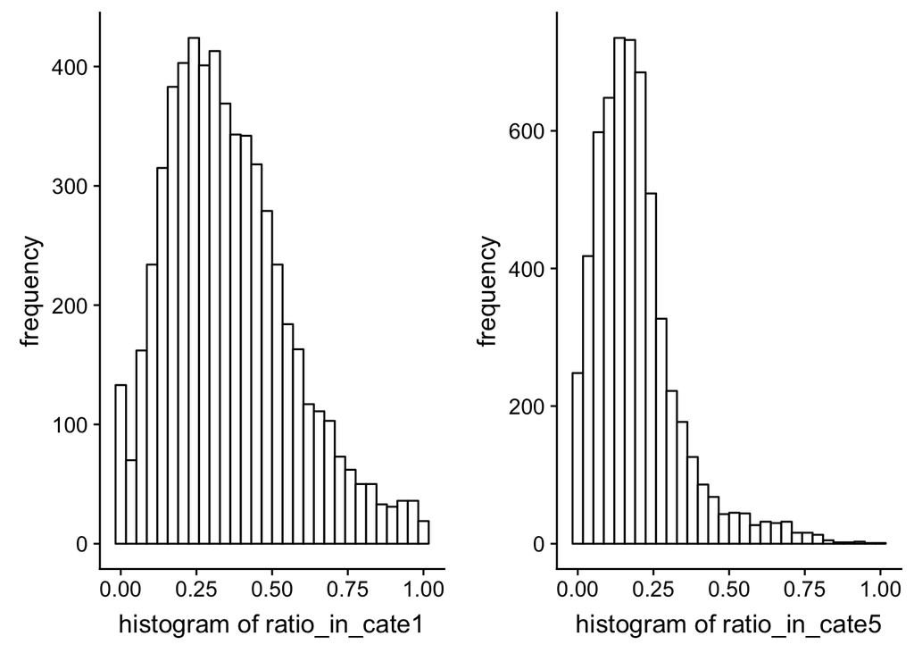

These two histograms show that customer have different preference on different category products.  
We could find ‘mountains and valleys’ patterns in these two graphs, indicating being potential segements for later analysis.

# Methods

## R

Load all the libraries we need for our analysis:

```r
library(cluster)
library(fpc)
library(ggplot2)
library(tidyr)
library(dplyr)
library(data.table)
```

### Data Preparation

We need to load data into R by using read.csv since it’s in csv format.

```r
dt=read.csv("https://raw.githubusercontent.com/Anranmg/project506/master/project506/final/BlackFriday.csv",header=TRUE, sep=',')
```

Product_category 2 and product_category 3 are products belong to other catagories, it recalculate same product, thus, we drop these two product_categories. By manipulating data, we get a new dataset with user_id, occupation, age, gender and ratio in 18 categories for each user.

`head` command allow us to check structure:

```r
head(data,1)
```

| User_ID | Occupation | Age | Gender | ratio_in_cate1 | ratio_in_cate2 | ratio_in_cate3 | ratio_in_cate4 | ratio_in_cate5 | ratio_in_cate6 | ratio_in_cate7 | ratio_in_cate8 | ratio_in_cate9 | ratio_in_cate10 | ratio_in_cate11 | ratio_in_cate12 | ratio_in_cate13 | ratio_in_cate14 | ratio_in_cate15 | ratio_in_cate16 | ratio_in_cate17 | ratio_in_cate18 |
| --- | --- | --- | --- | --- | --- | --- | --- | --- | --- | --- | --- | --- | --- | --- | --- | --- | --- | --- | --- | --- | --- |
| 1000001 | 10 | 0-17 | F | 0.1847302 | 0.03850894 | 0.3594178 | 0.01682854 | 0.04722608 | 0.04984392 | 0 | 0.2085336 | 0 | 0 | 0 | 0.01257643 | 0 | 0.03301837 | 0 | 0.04931615 | 0 | 0 |

Choosing ratio in categories as segementaion variables, and using euclidean distance measure to calculate pairwise distance. Then we show pairwise distance between first 5 consumers:

```
##           1         2         3         4         5
## 1 0.0000000 0.4986786 0.6375082 0.9205942 0.3926833
## 2 0.4986786 0.0000000 0.3304344 0.5740908 0.3024902
## 3 0.6375082 0.3304344 0.0000000 0.3907050 0.5466931
## 4 0.9205942 0.5740908 0.3907050 0.0000000 0.8491656
## 5 0.3926833 0.3024902 0.5466931 0.8491656 0.0000000
```

### Clustering Analysis

Using hierarchical clustering method, and get the dendrogram.  
Method: Agglomeration method  
Linkage: ward  
Use euclidean method to calculate distance.

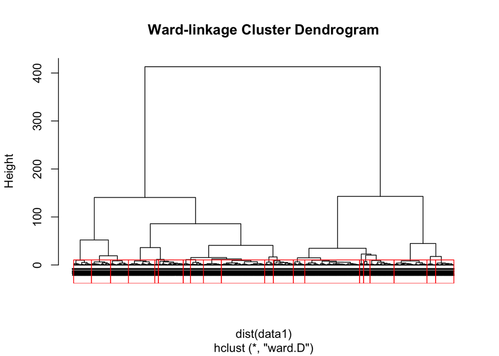

```r
plot(sol,cex = 0.3,hang = - 10, main = "Ward-linkage Cluster Dendrogram")
rect.hclust(sol, k=20, border="red")
```

Select number of clusters based on CH index. When clusters number is 2, calinhara has max value. Thus, choose 2 be the number of clusters with `cutree` command.

| no. | calinhara |
| --- | --- |
| 2 | 2640.9880 |
| 3 | 1920.5039 |
| 4 | 1910.1598 |
| 5 | 1737.1040 |
| 6 | 1569.2711 |
| 7 | 1409.9594 |
| 8 | 1315.2926 |
| 9 | 1243.7195 |
| 10 | 1201.2254 |
| 11 | 1160.0337 |

[output cut: 4 more lines]

```r
cluster_id = cutree(as.hclust(sol), k = 2)
```

Check the number of each cluster

```
## cluster_id
##    1    2
## 2487 3404
```

Clustering result in first 10 obs:

| User_ID | cluster_id |
| --- | --- |
| 1000001 | 1 |
| 1000002 | 1 |
| 1000003 | 1 |
| 1000004 | 1 |
| 1000005 | 2 |
| 1000006 | 1 |
| 1000007 | 1 |
| 1000008 | 2 |
| 1000009 | 2 |
| 1000010 | 2 |

### Analysis on Demographic Features

The plot shows average purchase proportion for each group and mean ourchase proportion for whole population.

| type | category | population | group1 | group2 |
| --- | --- | --- | --- | --- |
| ratio_in_cate1 | 1 | 0.3574883802 | 0.5324371387 | 0.2296688847 |
| ratio_in_cate10 | 10 | 0.0214522600 | 0.0166749169 | 0.0249426397 |
| ratio_in_cate11 | 11 | 0.0218461344 | 0.0298805106 | 0.0159761304 |
| ratio_in_cate12 | 12 | 0.0012126388 | 0.0008181838 | 0.0015008320 |
| ratio_in_cate13 | 13 | 0.0007596713 | 0.0006218516 | 0.0008603639 |
| ratio_in_cate14 | 14 | 0.0037908078 | 0.0017965338 | 0.0052478465 |
| ratio_in_cate15 | 15 | 0.0167196832 | 0.0215335486 | 0.0132026199 |
| ratio_in_cate16 | 16 | 0.0305505777 | 0.0227497190 | 0.0362499712 |
| ratio_in_cate17 | 17 | 0.0010500592 | 0.0008944274 | 0.0011637656 |
| ratio_in_cate18 | 18 | 0.0016683439 | 0.0018859601 | 0.0015093511 |

[output cut: 8 more lines]

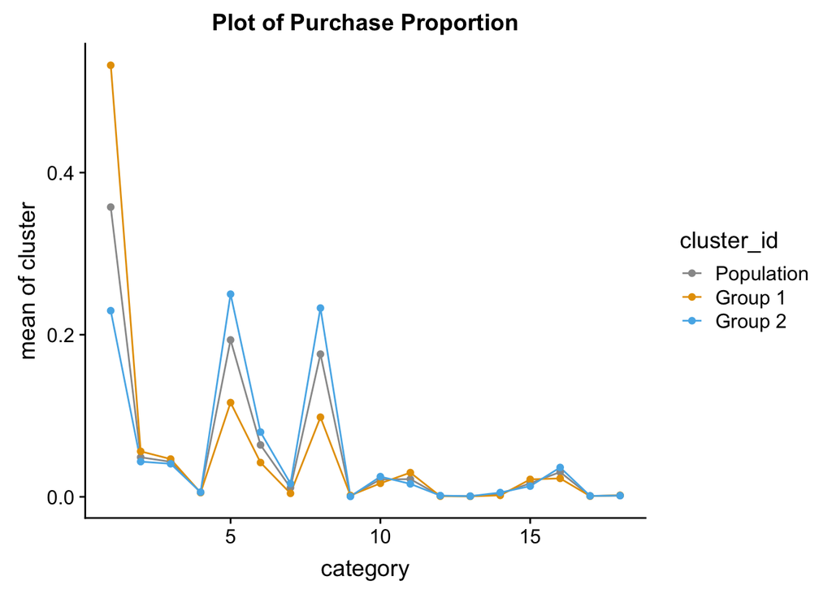

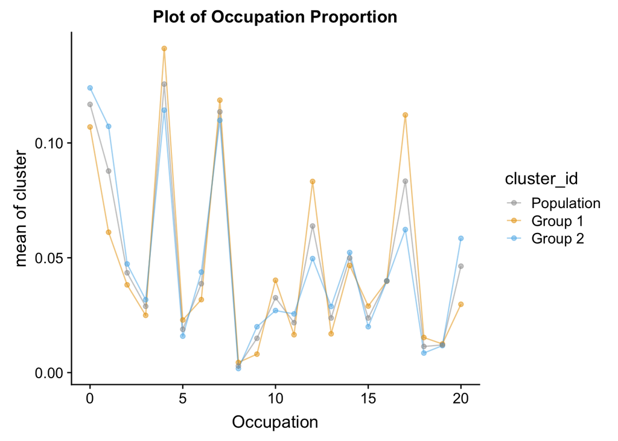

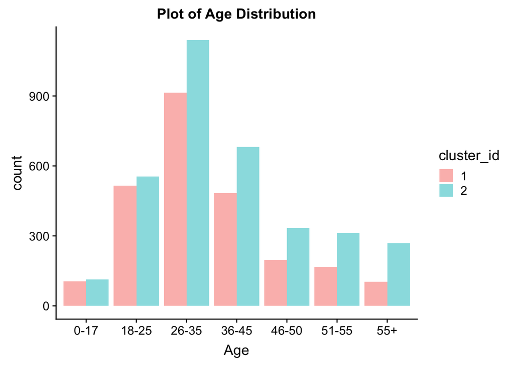

## Stata

### Data Prepartion

Similar to R and Python, we need to first import the dataset into STATA. We use the `import delimited` command.

```r
import delimited "https://raw.githubusercontent.com/Anranmg/project506/master/BlackFriday.csv"
```

We only use information in “product_category_1” for clustering analysis considered too many missing values in another two categories. In our clustering model, we use customer preference, defined as relative expense in each product category, to help identify market segments. Meanwhile, we use some of the remaining geo-demographic attribututes to profile the clusters. Therefore, we later reshaped the dataset to the wide format and obtain 18 different variables.

```r
reshape wide all_purchase, i(user_id) j(product_category_1)
```

To gain a overview of our consumer’s shopping preference, we use `summarize` command. And use `encode` command to convert string to numerical variables. As all our segmentation attributes are on the similar scale (0 to 1), we skip the feature scaling step.

```r
encode gender, gen(sex)
encode age, gen(nage)
encode city_category, gen(city)
encode stay_in_current_city_years, gen(stay_years)
summarize all_purchase*

    Variable |        Obs        Mean    Std. Dev.       Min        Max
-------------+---------------------------------------------------------
all_purch~e1 |      5,891    .3574884    .2054086          0          1
all_purch~e2 |      5,891    .0487926    .0535967          0   .5145295
all_purch~e3 |      5,891    .0432541    .0679692          0   .7986262
all_purch~e4 |      5,891    .0054967    .0099025          0   .1729248
all_purch~e5 |      5,891    .1935776    .1421216          0          1
-------------+---------------------------------------------------------
all_purch~e6 |      5,891     .064011    .0748471          0   .7285641
all_purch~e7 |      5,891    .0112639    .0371069          0   .8893259
all_purch~e8 |      5,891    .1760551    .1295851          0   .9368429
all_purcha~9 |      5,891    .0010103    .0059569          0   .2057311
all_purch~10 |      5,891    .0214523    .0480529          0   .6188408
-------------+---------------------------------------------------------
all_purch~11 |      5,891    .0218461    .0511153          0   .7596826
all_purch~12 |      5,891    .0012126    .0045447          0   .1463652
all_purch~13 |      5,891    .0007597    .0019349          0   .0402441
all_purch~14 |      5,891    .0037908    .0142612          0   .3009311
all_purch~15 |      5,891    .0167197    .0337391          0   .7496737
-------------+---------------------------------------------------------
all_purch~16 |      5,891    .0305506    .0474592          0     .44275
all_purch~17 |      5,891    .0010501    .0060297          0   .1240658
all_purch~18 |      5,891    .0016683    .0078574          0   .3889048
```

### Clustering Analysis

Since our goal is to group customer based on how similiar taste they have for shopping, we use euclidean distance measure as well as ward linkage method. `dendrogram` command allows us to visualize the clustering results (shown in Figure1).

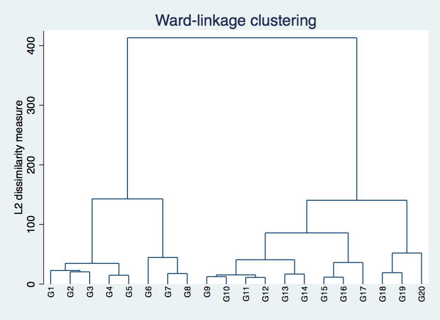

```r
cluster wardslinkage all_purchase*, measure(Euclidean) name(ward)
cluster list ward

ward  (type: hierarchical,  method: wards,  dissimilarity: L2)
      vars: ward_id (id variable)
            ward_ord (order variable)
            ward_hgt (height variable)
     other: cmd: cluster wardslinkage all_purchase*, measure(Euclidean) name(ward)
            varlist: all_purchase1 all_purchase2 all_purchase3 all_purchase4
                 all_purchase5 all_purchase6 all_purchase7 all_purchase8
                 all_purchase9 all_purchase10 all_purchase11 all_purchase12
                 all_purchase13 all_purchase14 all_purchase15 all_purchase16
                 all_purchase17 all_purchase18
            range: 0 .

cluster dendrogram ward, xlabel(, angle(90) labsize(*.75)) cutnumber(20) title(Ward-linkage clustering)
```

For simplicity, we use the Calinski Harabasz method to choose no. of clusters. Based on that, we finally use 2-segments solution and the segmentation result is shown as following.

```r
cluster stop ward

+---------------------------+
|             |  Calinski/  |
|  Number of  |  Harabasz   |
|  clusters   |  pseudo-F   |
|-------------+-------------|
|      2      |   2640.99   |
|      3      |   1920.50   |
|      4      |   1910.16   |
|      5      |   1737.10   |
|      6      |   1569.27   |
|      7      |   1409.96   |
|      8      |   1315.29   |
|      9      |   1243.72   |
|     10      |   1201.23   |
|     11      |   1160.03   |
|     12      |   1117.24   |
|     13      |   1068.26   |
|     14      |   1009.08   |
|     15      |    982.52   |
+---------------------------+
```

We use `list` command to show the clustering result of our first ten consumers.

```r
list user_id group in 1/10

     +-----------------+
     | user_id   group |
     |-----------------|
  1. | 1000001       1 |
  2. | 1000002       1 |
  3. | 1000003       1 |
  4. | 1000004       1 |
  5. | 1000005       2 |
     |-----------------|
  6. | 1000006       1 |
  7. | 1000007       1 |
  8. | 1000008       2 |
  9. | 1000009       2 |
 10. | 1000010       2 |
     +-----------------+
```

We also plot a line chart to compare difference between groups:

- it is apparent that compared with *two groups*, customers in group one spend much more in *category 1* while they are less likely attracted by products in *category 5 and 8*.
- Also, we can find people clustered in *group two* have some relatively preference on *category 5 and 8*.
- Based on these results, the company could set tailored promotion strategy on different groups of people.

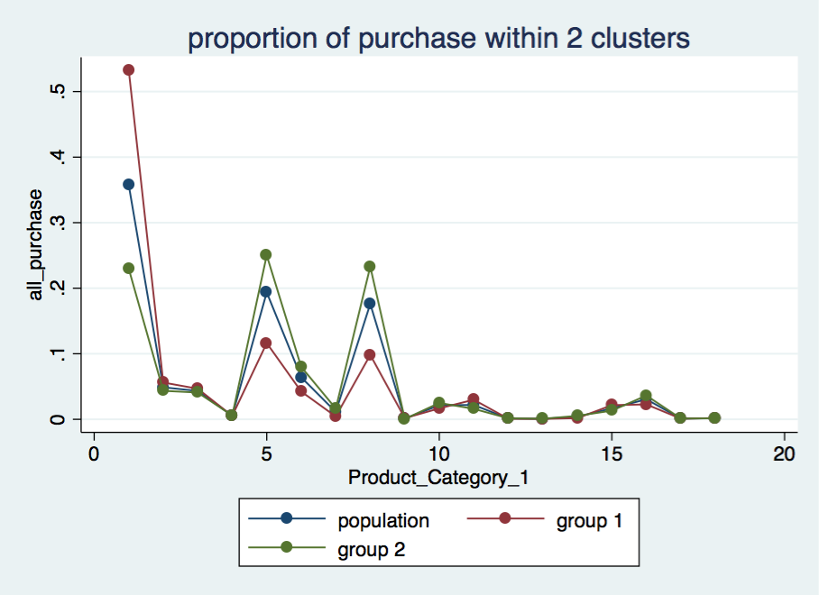

### Analysis on Demographic Features

Combined demographic features, we use the following plots to help detect divergence among these two clusters:

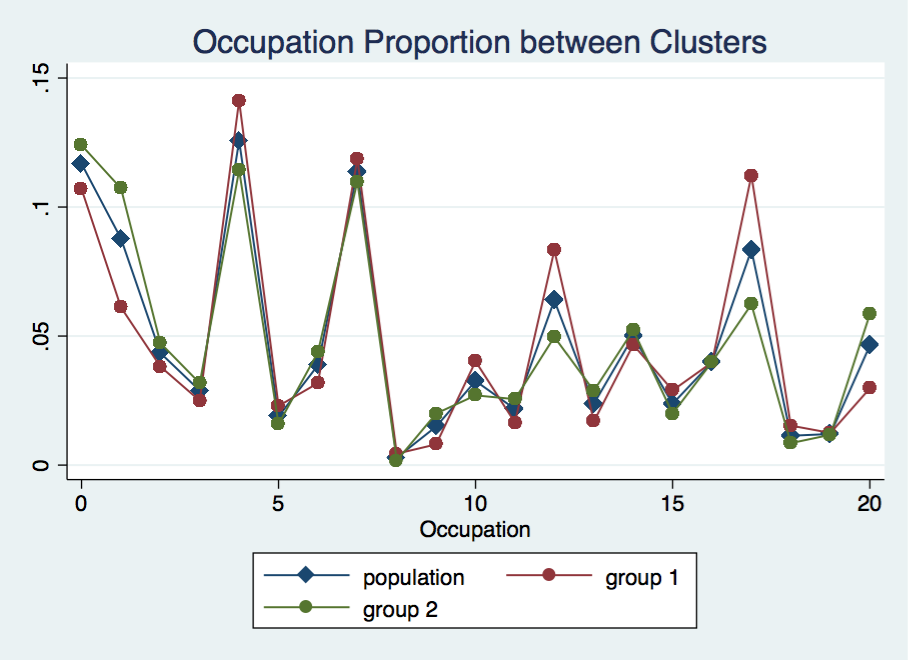

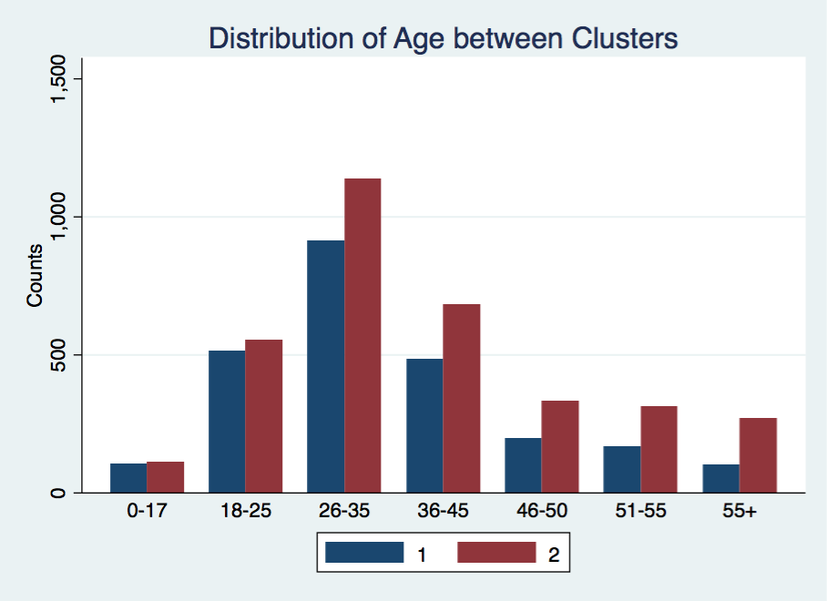

## Python

```python
from matplotlib import pyplot as plt
from scipy.cluster.hierarchy import dendrogram, linkage
from sklearn import preprocessing
import numpy as np
import pandas as pd
%matplotlib inline
```

```python
crimerate_data = pd.read_csv('USArrests.csv')
```

### Data Preparation

#### Normalize the features to make variables comparable

```python
statesList = crimerate_data.iloc[:, 0].values # label
data = crimerate_data.iloc[:, 1:5].values
```

```python
data_scaled = preprocessing.scale(data)
```

We can check the normalized results by

```python
data_scaled.mean(axis=0)
```

```
array([-7.10542736e-17,  1.38777878e-16, -4.39648318e-16,  8.59312621e-16])
```

```python
data_scaled.std(axis=0)
```

```
array([1., 1., 1., 1.])
```

### Perform the Hierarchical Clustering

```python
# generate the linkage matrix ('average' method is selected)
linked = linkage(data_scaled, 'average')
```

#### To check the [Cophenetic Correlation Coefficient](https://en.wikipedia.org/wiki/Cophenetic_correlation)

```python
from scipy.cluster.hierarchy import cophenet
from scipy.spatial.distance import pdist # computing the distance

c, coph_dists = cophenet(linked, pdist(data_scaled))
```

The closer the value is to 1, the better the clustering preserves the original distances

```python
c
```

```
0.7180382379320472
```

#### The Linkage Matrix

The linkage matrix is an array of length `n - 1`, where `n` is the number of our starting singleton clusters.  
`linked[i]` includes the information of which two clusters are merged at iteration `i` according the selected evalutation metric.  
For example:

```python
linked[0]
```

```
array([14.       , 28.       ,  0.2079438,  2.       ])
```

The returned array is in the format of `[idx1, idx2, dist, sample_count]`. Therefore, at iteration `0`, since indices `14` and `28` only have a distance of `0.2079438`, they are merged together first.

```python
linked[:10]
```

```
array([[14.        , 28.        ,  0.2079438 ,  2.        ],
       [12.        , 31.        ,  0.35377437,  2.        ],
       [13.        , 15.        ,  0.43312429,  2.        ],
       [22.        , 48.        ,  0.49909939,  2.        ],
       [35.        , 52.        ,  0.53043045,  3.        ],
       [19.        , 30.        ,  0.54082482,  2.        ],
       [18.        , 50.        ,  0.57847034,  3.        ],
       [36.        , 46.        ,  0.59956023,  2.        ],
       [45.        , 54.        ,  0.67765914,  4.        ],
       [40.        , 47.        ,  0.71809843,  2.        ]])
```

It can be noticed that `idx2` of `linked[4]` is `52`, but we only have `50` data points in total. Actually, all `idx >= 50` represents the cluster gererated in `linked[idx - 50]`. Therefore, for this case it just means to merge sample `35 (Oklahoma)` to our samples `13 (Indiana)` and `15 (Kansas)`.

#### Plotting a Dendrogram

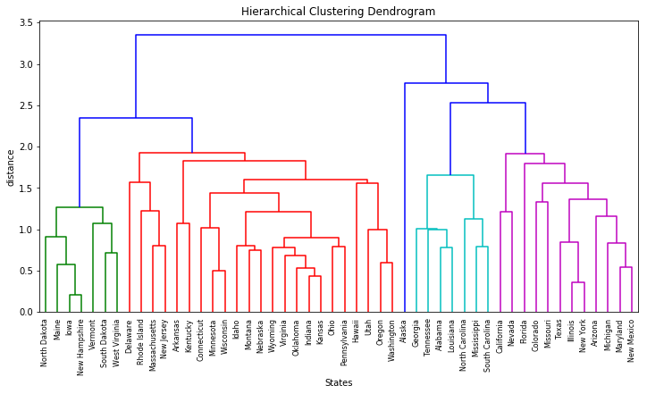

```python
plt.figure(figsize=(12, 6))
plt.title('Hierarchical Clustering Dendrogram')
plt.xlabel('States')
plt.ylabel('distance')
dendrogram(linked,
           orientation='top', #The direction to plot the dendrogram
                              #The root at the top, and descendent links going downwards
           labels=statesList,
           distance_sort='descending',
           show_leaf_counts=True)
plt.show()
```

According to [this](http://nbviewer.jupyter.org/github/OxanaSachenkova/hclust-python/blob/master/hclust.ipynb), we can visualize the distance between clusters by plotting the heatmap

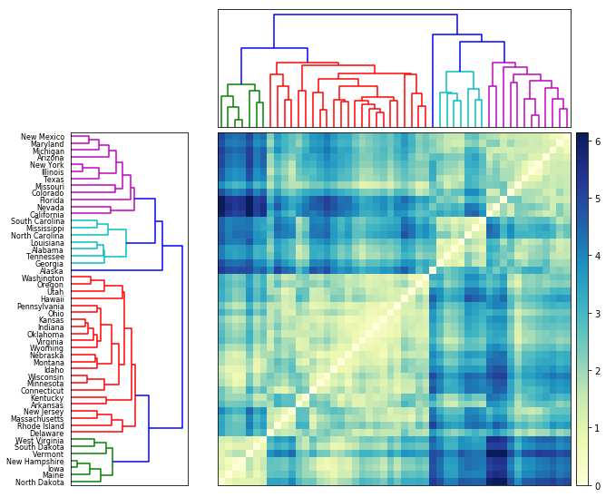

```python
# the following code is modified based on
# http://nbviewer.jupyter.org/github/OxanaSachenkova/hclust-python/blob/master/hclust.ipynb
from scipy.spatial.distance import squareform

# Compute and plot first dendrogram.
fig = plt.figure(figsize=(9,9))
# x ywidth height
ax1 = fig.add_axes([0.05,0.1,0.2,0.6])
Y = linked
Z1 = dendrogram(Y, orientation='right',labels=statesList) # adding/removing the axes
ax1.set_xticks([])

# Compute and plot second dendrogram.
ax2 = fig.add_axes([0.3,0.71,0.6,0.2])
Z2 = dendrogram(Y)
ax2.set_xticks([])
ax2.set_yticks([])

#Compute and plot the heatmap
axmatrix = fig.add_axes([0.3,0.1,0.6,0.6])
idx1 = Z1['leaves']
idx2 = Z2['leaves']
D = squareform(pdist(data_scaled))
D = D[idx1,:]
D = D[:,idx2]
im = axmatrix.matshow(D, aspect='auto', origin='lower', cmap=plt.cm.YlGnBu)
axmatrix.set_xticks([])
axmatrix.set_yticks([])

# Plot colorbar.
axcolor = fig.add_axes([0.91,0.1,0.02,0.6])
plt.colorbar(im, cax=axcolor)
```

### Determining the Number of Clusters

#### Elbow Method

According to wikipedia, the goal is to minimize the total intra-cluster variation:
$$\arg\min_{\vec{S}}\sum_{i=1}^k\sum_{\vec{x}\in S_i}||\vec{x}-\mu_i||$$
where we partition a set of observations $\vec{x} = (x_1, x_2, …, x_n)$ into k ($\leq n$) sets $\vec{S} = {S_1, S_2, …, S_k}$

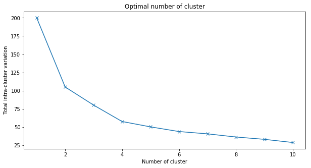

```python
from sklearn.cluster import KMeans

cluster_range = range(1, 11)
wss = []

for num_clusters in cluster_range:
  clusters = KMeans( num_clusters )
  clusters.fit( data_scaled )
  wss.append( clusters.inertia_ )



plt.figure(figsize=(10,5))
plt.title('Optimal number of cluster')
plt.xlabel('Number of cluster')
plt.ylabel('Total intra-cluster variation')
plt.plot(cluster_range, wss, marker = "x")
```

To help find the “elbow”, we can check the 2nd derivative of the WSS

```python
accele = np.diff(wss, 2)
```

The gain in explained variance reduces significantly from 3 to 4 to 5. So, optimal number of clusters could be either 4 or 5.

```python
accele
```

```
array([70.16242895,  2.34450127, 15.14053614,  0.98549108,  3.23530266,
       -1.18339029,  1.15781744, -1.15034157])
```

Alternatively, we can just focus on finding where the acceleration of distance growth is the biggest:

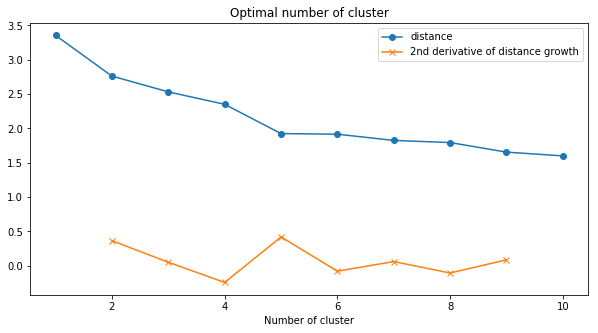

```
clusters: 5
```

```python
last = linked[-10:, 2]
last_rev = last[::-1]
idxs = np.arange(1, len(last) + 1)

plt.figure(figsize=(10,5))
plt.title('Optimal number of cluster')
plt.xlabel('Number of cluster')

plt.plot(idxs, last_rev, marker = "o", label="distance")

accele = np.diff(last, 2)  # 2nd derivative of the distances
accele_rev = accele[::-1]
plt.plot(idxs[:-2] + 1, accele_rev, marker = "x", label = "2nd derivative of distance growth")

plt.legend()
plt.show()
k = accele_rev.argmax() + 2  # if idx 0 is the max of this we want 2 clusters
print ("clusters:", k)
```

### Plot Annotated Hierarchical Clustering Dendrograms

We can plot the annotated truncated dendrogram with cut-off line by using [fancy_dendrogram()](https://joernhees.de/blog/2015/08/26/scipy-hierarchical-clustering-and-dendrogram-tutorial/)

```python
# the following code is from
# [https://joernhees.de/blog/2015/08/26/scipy-hierarchical-clustering-and-dendrogram-tutorial/]
def fancy_dendrogram(*args, **kwargs):
    plt.figure(figsize=(10,5))
    max_d = kwargs.pop('max_d', None)
    if max_d and 'color_threshold' not in kwargs:
        kwargs['color_threshold'] = max_d
    annotate_above = kwargs.pop('annotate_above', 0)

    ddata = dendrogram(*args, **kwargs)

    if not kwargs.get('no_plot', False):
        plt.title('Hierarchical Clustering Dendrogram (truncated)')
        plt.xlabel('sample index or (cluster size)')
        plt.ylabel('distance')
        for i, d, c in zip(ddata['icoord'], ddata['dcoord'], ddata['color_list']):
            x = 0.5 * sum(i[1:3])
            y = d[1]
            if y > annotate_above:
                plt.plot(x, y, 'o', c=c)
                plt.annotate("%.3g" % y, (x, y), xytext=(0, -5),
                             textcoords='offset points',
                             va='top', ha='center')
        if max_d:
            plt.axhline(y=max_d, c='k')
    return ddata
```

#### Four clusters

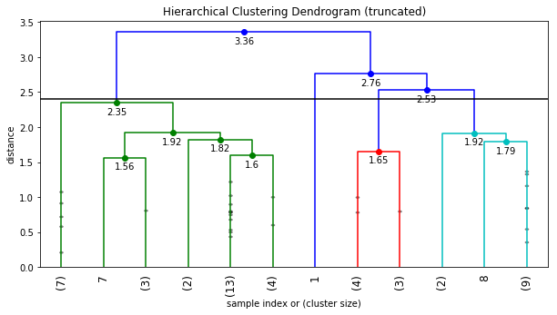

```python
fancy_dendrogram(
    linked,
    truncate_mode='lastp',
    p=12,
    leaf_rotation=90.,
    leaf_font_size=12.,
    show_contracted=True,
    annotate_above=1,
    max_d=2.4,  # a horizontal cut-off line
)

plt.show()
```

#### Five clusters

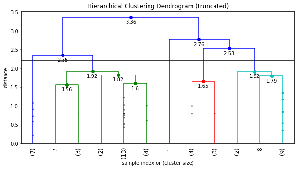

```python
fancy_dendrogram(
    linked,
    truncate_mode='lastp',
    p=12,
    leaf_rotation=90.,
    leaf_font_size=12.,
    show_contracted=True,
    annotate_above=1,
    max_d=2.2,  # a horizontal cut-off line
)

plt.show()
```

# Things to Consider

There is some potential risk in our analysis. For example, it might be to early to draw the conclusion on occupation as some other features have strong impact on consumer’s shopping preference. Additionally, for time limited, we skip the robustness check step. It could hurt the validness of our clustering results.

# References

1. [*A Dendrite Method for Cluster Analysis*](https://www.tandfonline.com/doi/pdf/10.1080/03610927408827101)
2. [*Euclidean Distance*](https://en.wikipedia.org/wiki/Euclidean_distance)
3. [*Ward’s Method*](https://www.stat.cmu.edu/~cshalizi/350/lectures/08/lecture-08.pdf)
4. [*Hierarchical agglomerative clustering*](https://nlp.stanford.edu/IR-book/html/htmledition/hierarchical-agglomerative-clustering-1.html)
5. [*Divisive clustering*](https://en.wikipedia.org/wiki/Hierarchical_clustering#Divisive_clustering)

# Link to Github

All the materials can be found in our [Github](https://github.com/Anranmg/project506/tree/master/final).